# Processing reads, mapping, and building a count matrix

### Make count matrix of peaks, starting with reading in HOMER peak files and making a matrix that indicated which peaks were called in each sample

```r
#read in peak files and convert to GRanges
read_peaks <- lapply(peaks,function(x)read.delim(x,sep="\t",comment.char = "#",h=FALSE))
read_peaksGR <- lapply(read_peaks,
                       function(x)GRanges(x$V2,IRanges(x$V3,x$V4),strand = x$V5))
names(read_peaksGR) <- gsub( paste0(baseDir,"/"), "",  (unlist(peaks)))
read_peaksGRList <- GRangesList(read_peaksGR)
GRSet <- unlist(read_peaksGRList)
nGRSet <- reduce(GRSet)
peakmat <- do.call(cbind,lapply(read_peaksGRList,
                                function(x)
                                  nGRSet %over% x))
mcols(nGRSet) <- peakmat

#now you have a peakmat where rows are a reduced set of peaks (without an identifier for the time being), and each column  is whether or not the peak was called in that sample
head(peakmat)
```

```
##      KRG091819_S1_L001_R1_001_collapse_rm5_Aag2_Ago1_Exp6A_trim_clip/peaks.txt
## [1,]                                                                     FALSE
## [2,]                                                                     FALSE
## [3,]                                                                     FALSE
## [4,]                                                                      TRUE
## [5,]                                                                     FALSE
## [6,]                                                                      TRUE
##      KRG091819_S1_L001_R1_001_collapse_rm5_Aag2_Ago1_Exp6B_trim_clip/peaks.txt
## [1,]                                                                     FALSE
## [2,]                                                                     FALSE
## [3,]                                                                     FALSE
## [4,]                                                                     FALSE
## [5,]                                                                      TRUE
## [6,]                                                                     FALSE
##      KRG092419_S1_L001_R1_001_collapse_Aag2_Ago1_Exp7A_rm5_clip/peaks.txt
## [1,]                                                                FALSE
## [2,]                                                                 TRUE
## [3,]                                                                 TRUE
## [4,]                                                                FALSE
## [5,]                                                                FALSE
## [6,]                                                                FALSE
##      KRG092419_S1_L001_R1_001_collapse_Aag2_Ago1_Exp7B_rm5_clip/peaks.txt
## [1,]                                                                 TRUE
## [2,]                                                                FALSE
## [3,]                                                                FALSE
## [4,]                                                                FALSE
## [5,]                                                                 TRUE
## [6,]                                                                FALSE
```

### The next step is to countFromBed to append the number of reads at each peak location, by sample

CLIPflexR documentation

```r
#defaults are: notStranded=TRUE,interFeature=FALSE
countmat <- lapply(beds,countFromBed,GR=nGRSet)
countmat <- do.call(cbind,countmat)
colnames(countmat) <- basename(unlist(beds))

#now bind nGRSet, a GRanges with peak ranges and TRUE/FALSE at each peak, with countmat, the number of reads at each peak
mcols(nGRSet) <- cbind(as.data.frame(mcols(nGRSet)),countmat)

#you can convert this GRanges object to a dataframe
peaksDF <- as.data.frame(nGRSet)
peaksDF$peakID <- paste0(peaksDF$seqnames, ":", peaksDF$start, "_", peaksDF$end, ":", peaksDF$strand)
head(peaksDF)
```

```
##   seqnames   start     end width strand
## 1        1  301043  301053    11      +
## 2        1  580903  580913    11      +
## 3        1 1183109 1183119    11      +
## 4        1 1386212 1386222    11      +
## 5        1 1947557 1947569    13      +
## 6        1 1947625 1947635    11      +
##   KRG091819_S1_L001_R1_001_collapse_rm5_Aag2_Ago1_Exp6A_trim_clip.peaks.txt
## 1                                                                     FALSE
## 2                                                                     FALSE
## 3                                                                     FALSE
## 4                                                                      TRUE
## 5                                                                     FALSE
## 6                                                                      TRUE
##   KRG091819_S1_L001_R1_001_collapse_rm5_Aag2_Ago1_Exp6B_trim_clip.peaks.txt
```

[output cut: 55 more lines]

### now you have your count matrix!

### you can perform operations on sample groups to filter, visualize data, annotate your peaks, and more…

For example, if you are dealing with a custom genome without pre-built genomes and annotation, you can still easily annotate your peaks  
Here we provide an example using [ChIPseeker](http://bioconductor.org/packages/release/bioc/html/ChIPseeker.html), which you can also use to visualize genomic annotation (see ChIPseeker vignette for alternate visualizations)

```r
#load required packages
library(ChIPseeker)
library(GenomicFeatures)

gtffile <- "/Users/kathryn/Aedes-aegypti-LVP_AGWG_BASEFEATURES_AaegL5.2.gtf"  #custom gtf or gff

TxDb <- makeTxDbFromGFF(gtffile)
```

```
## Import genomic features from the file as a GRanges object ... OK
## Prepare the 'metadata' data frame ... OK
## Make the TxDb object ...
```

```
## OK
```

```r
allanno <- annotatePeak(nGRSet,
                              TxDb=TxDb,
                              sameStrand=FALSE,
                              genomicAnnotationPriority = c("3UTR", "5UTR", "Exon",
                                                            "Intron", "Promoter", "Downstream", "Intergenic"),
                              overlap = "all")
```

```
## >> preparing features information...      2021-03-16 02:33:31
## >> identifying nearest features...        2021-03-16 02:33:31
```

```
## >> calculating distance from peak to TSS...   2021-03-16 02:33:31
## >> assigning genomic annotation...        2021-03-16 02:33:31
```

```
## >> assigning chromosome lengths           2021-03-16 02:33:35
## >> done...                    2021-03-16 02:33:35
```

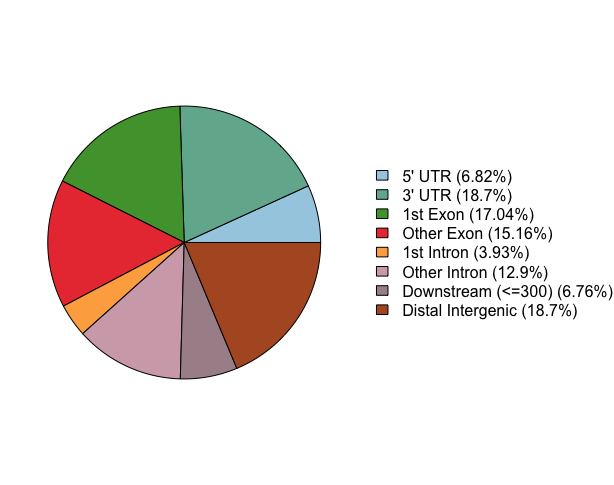

```r
plotAnnoPie(allanno)
```